# Risk Factor Analysis

## Outcome Variable

**Outcome Variable:** ever_stunted

## Predictor Variables

**Intervention Variable:** perdiar24

**Adjustment Set:**

unadjusted

## Stratifying Variables

The analysis was stratified on these variable(s):

- agecat
- studyid
- country

## Data Summary

| agecat | studyid | country | perdiar24 | ever_stunted | n_cell | n |
| --- | --- | --- | --- | --- | --- | --- |
| 0-24 months (no birth st.) | ki0047075b-MAL-ED | BANGLADESH | 0% | 0 | 9 | 217 |
| 0-24 months (no birth st.) | ki0047075b-MAL-ED | BANGLADESH | 0% | 1 | 7 | 217 |
| 0-24 months (no birth st.) | ki0047075b-MAL-ED | BANGLADESH | (0%, 5%] | 0 | 63 | 217 |
| 0-24 months (no birth st.) | ki0047075b-MAL-ED | BANGLADESH | (0%, 5%] | 1 | 65 | 217 |
| 0-24 months (no birth st.) | ki0047075b-MAL-ED | BANGLADESH | >5% | 0 | 31 | 217 |
| 0-24 months (no birth st.) | ki0047075b-MAL-ED | BANGLADESH | >5% | 1 | 42 | 217 |
| 0-24 months (no birth st.) | ki0047075b-MAL-ED | BRAZIL | 0% | 0 | 99 | 202 |
| 0-24 months (no birth st.) | ki0047075b-MAL-ED | BRAZIL | 0% | 1 | 14 | 202 |
| 0-24 months (no birth st.) | ki0047075b-MAL-ED | BRAZIL | (0%, 5%] | 0 | 69 | 202 |
| 0-24 months (no birth st.) | ki0047075b-MAL-ED | BRAZIL | (0%, 5%] | 1 | 18 | 202 |
| 0-24 months (no birth st.) | ki0047075b-MAL-ED | BRAZIL | >5% | 0 | 2 | 202 |
| 0-24 months (no birth st.) | ki0047075b-MAL-ED | BRAZIL | >5% | 1 | 0 | 202 |
| 0-24 months (no birth st.) | ki0047075b-MAL-ED | INDIA | 0% | 0 | 9 | 210 |
| 0-24 months (no birth st.) | ki0047075b-MAL-ED | INDIA | 0% | 1 | 3 | 210 |
| 0-24 months (no birth st.) | ki0047075b-MAL-ED | INDIA | (0%, 5%] | 0 | 71 | 210 |
| 0-24 months (no birth st.) | ki0047075b-MAL-ED | INDIA | (0%, 5%] | 1 | 91 | 210 |
| 0-24 months (no birth st.) | ki0047075b-MAL-ED | INDIA | >5% | 0 | 19 | 210 |
| 0-24 months (no birth st.) | ki0047075b-MAL-ED | INDIA | >5% | 1 | 17 | 210 |
| 0-24 months (no birth st.) | ki0047075b-MAL-ED | NEPAL | 0% | 0 | 12 | 211 |
| 0-24 months (no birth st.) | ki0047075b-MAL-ED | NEPAL | 0% | 1 | 2 | 211 |
| 0-24 months (no birth st.) | ki0047075b-MAL-ED | NEPAL | (0%, 5%] | 0 | 94 | 211 |
| 0-24 months (no birth st.) | ki0047075b-MAL-ED | NEPAL | (0%, 5%] | 1 | 36 | 211 |
| 0-24 months (no birth st.) | ki0047075b-MAL-ED | NEPAL | >5% | 0 | 50 | 211 |
| 0-24 months (no birth st.) | ki0047075b-MAL-ED | NEPAL | >5% | 1 | 17 | 211 |
| 0-24 months (no birth st.) | ki0047075b-MAL-ED | PERU | 0% | 0 | 21 | 266 |
| 0-24 months (no birth st.) | ki0047075b-MAL-ED | PERU | 0% | 1 | 6 | 266 |
| 0-24 months (no birth st.) | ki0047075b-MAL-ED | PERU | (0%, 5%] | 0 | 34 | 266 |
| 0-24 months (no birth st.) | ki0047075b-MAL-ED | PERU | (0%, 5%] | 1 | 65 | 266 |
| 0-24 months (no birth st.) | ki0047075b-MAL-ED | PERU | >5% | 0 | 60 | 266 |
| 0-24 months (no birth st.) | ki0047075b-MAL-ED | PERU | >5% | 1 | 80 | 266 |

[output cut: 270 more lines]

The following strata were considered:

- agecat: 0-24 months (no birth st.), studyid: ki0047075b-MAL-ED, country: BANGLADESH
- agecat: 0-24 months (no birth st.), studyid: ki0047075b-MAL-ED, country: BRAZIL
- agecat: 0-24 months (no birth st.), studyid: ki0047075b-MAL-ED, country: INDIA
- agecat: 0-24 months (no birth st.), studyid: ki0047075b-MAL-ED, country: NEPAL
- agecat: 0-24 months (no birth st.), studyid: ki0047075b-MAL-ED, country: PERU
- agecat: 0-24 months (no birth st.), studyid: ki0047075b-MAL-ED, country: SOUTH AFRICA
- agecat: 0-24 months (no birth st.), studyid: ki0047075b-MAL-ED, country: TANZANIA, UNITED REPUBLIC OF
- agecat: 0-24 months (no birth st.), studyid: ki1000109-EE, country: PAKISTAN
- agecat: 0-24 months (no birth st.), studyid: ki1000304b-SAS-FoodSuppl, country: INDIA
- agecat: 0-24 months (no birth st.), studyid: ki1017093-NIH-Birth, country: BANGLADESH
- agecat: 0-24 months (no birth st.), studyid: ki1017093b-PROVIDE, country: BANGLADESH
- agecat: 0-24 months (no birth st.), studyid: ki1017093c-NIH-Crypto, country: BANGLADESH
- agecat: 0-24 months (no birth st.), studyid: ki1112895-Guatemala BSC, country: GUATEMALA
- agecat: 0-24 months (no birth st.), studyid: ki1112895-iLiNS-Zinc, country: BURKINA FASO
- agecat: 0-24 months (no birth st.), studyid: ki1114097-CMIN, country: BANGLADESH
- agecat: 0-24 months (no birth st.), studyid: ki1114097-CONTENT, country: PERU
- agecat: 0-24 months (no birth st.), studyid: kiGH5241-JiVitA-4, country: BANGLADESH
- agecat: 0-6 months (no birth st.), studyid: ki0047075b-MAL-ED, country: BANGLADESH
- agecat: 0-6 months (no birth st.), studyid: ki0047075b-MAL-ED, country: BRAZIL
- agecat: 0-6 months (no birth st.), studyid: ki0047075b-MAL-ED, country: INDIA
- agecat: 0-6 months (no birth st.), studyid: ki0047075b-MAL-ED, country: NEPAL
- agecat: 0-6 months (no birth st.), studyid: ki0047075b-MAL-ED, country: PERU
- agecat: 0-6 months (no birth st.), studyid: ki0047075b-MAL-ED, country: SOUTH AFRICA
- agecat: 0-6 months (no birth st.), studyid: ki0047075b-MAL-ED, country: TANZANIA, UNITED REPUBLIC OF
- agecat: 0-6 months (no birth st.), studyid: ki1000109-EE, country: PAKISTAN
- agecat: 0-6 months (no birth st.), studyid: ki1000304b-SAS-FoodSuppl, country: INDIA
- agecat: 0-6 months (no birth st.), studyid: ki1017093-NIH-Birth, country: BANGLADESH
- agecat: 0-6 months (no birth st.), studyid: ki1017093b-PROVIDE, country: BANGLADESH
- agecat: 0-6 months (no birth st.), studyid: ki1017093c-NIH-Crypto, country: BANGLADESH
- agecat: 0-6 months (no birth st.), studyid: ki1112895-Guatemala BSC, country: GUATEMALA
- agecat: 0-6 months (no birth st.), studyid: ki1114097-CMIN, country: BANGLADESH
- agecat: 0-6 months (no birth st.), studyid: ki1114097-CONTENT, country: PERU
- agecat: 0-6 months (no birth st.), studyid: kiGH5241-JiVitA-4, country: BANGLADESH
- agecat: 6-24 months, studyid: ki0047075b-MAL-ED, country: BANGLADESH
- agecat: 6-24 months, studyid: ki0047075b-MAL-ED, country: BRAZIL
- agecat: 6-24 months, studyid: ki0047075b-MAL-ED, country: INDIA
- agecat: 6-24 months, studyid: ki0047075b-MAL-ED, country: NEPAL
- agecat: 6-24 months, studyid: ki0047075b-MAL-ED, country: PERU
- agecat: 6-24 months, studyid: ki0047075b-MAL-ED, country: SOUTH AFRICA
- agecat: 6-24 months, studyid: ki0047075b-MAL-ED, country: TANZANIA, UNITED REPUBLIC OF
- agecat: 6-24 months, studyid: ki1000109-EE, country: PAKISTAN
- agecat: 6-24 months, studyid: ki1000304b-SAS-FoodSuppl, country: INDIA
- agecat: 6-24 months, studyid: ki1017093-NIH-Birth, country: BANGLADESH
- agecat: 6-24 months, studyid: ki1017093b-PROVIDE, country: BANGLADESH
- agecat: 6-24 months, studyid: ki1017093c-NIH-Crypto, country: BANGLADESH
- agecat: 6-24 months, studyid: ki1112895-Guatemala BSC, country: GUATEMALA
- agecat: 6-24 months, studyid: ki1112895-iLiNS-Zinc, country: BURKINA FASO
- agecat: 6-24 months, studyid: ki1114097-CMIN, country: BANGLADESH
- agecat: 6-24 months, studyid: ki1114097-CONTENT, country: PERU
- agecat: 6-24 months, studyid: kiGH5241-JiVitA-4, country: BANGLADESH

### Dropped Strata

Some strata were dropped due to rare outcomes:

- agecat: 0-24 months (no birth st.), studyid: ki0047075b-MAL-ED, country: BRAZIL
- agecat: 0-24 months (no birth st.), studyid: ki0047075b-MAL-ED, country: INDIA
- agecat: 0-24 months (no birth st.), studyid: ki0047075b-MAL-ED, country: NEPAL
- agecat: 0-24 months (no birth st.), studyid: ki0047075b-MAL-ED, country: SOUTH AFRICA
- agecat: 0-24 months (no birth st.), studyid: ki1000109-EE, country: PAKISTAN
- agecat: 0-24 months (no birth st.), studyid: ki1017093b-PROVIDE, country: BANGLADESH
- agecat: 0-24 months (no birth st.), studyid: ki1114097-CMIN, country: BANGLADESH
- agecat: 0-24 months (no birth st.), studyid: ki1114097-CONTENT, country: PERU
- agecat: 0-6 months (no birth st.), studyid: ki0047075b-MAL-ED, country: BANGLADESH
- agecat: 0-6 months (no birth st.), studyid: ki0047075b-MAL-ED, country: BRAZIL
- agecat: 0-6 months (no birth st.), studyid: ki0047075b-MAL-ED, country: INDIA
- agecat: 0-6 months (no birth st.), studyid: ki0047075b-MAL-ED, country: NEPAL
- agecat: 0-6 months (no birth st.), studyid: ki0047075b-MAL-ED, country: SOUTH AFRICA
- agecat: 0-6 months (no birth st.), studyid: ki0047075b-MAL-ED, country: TANZANIA, UNITED REPUBLIC OF
- agecat: 0-6 months (no birth st.), studyid: ki1000109-EE, country: PAKISTAN
- agecat: 0-6 months (no birth st.), studyid: ki1000304b-SAS-FoodSuppl, country: INDIA
- agecat: 0-6 months (no birth st.), studyid: ki1017093-NIH-Birth, country: BANGLADESH
- agecat: 0-6 months (no birth st.), studyid: ki1017093b-PROVIDE, country: BANGLADESH
- agecat: 0-6 months (no birth st.), studyid: ki1112895-Guatemala BSC, country: GUATEMALA
- agecat: 0-6 months (no birth st.), studyid: ki1114097-CMIN, country: BANGLADESH
- agecat: 0-6 months (no birth st.), studyid: ki1114097-CONTENT, country: PERU
- agecat: 6-24 months, studyid: ki0047075b-MAL-ED, country: BANGLADESH
- agecat: 6-24 months, studyid: ki0047075b-MAL-ED, country: BRAZIL
- agecat: 6-24 months, studyid: ki0047075b-MAL-ED, country: INDIA
- agecat: 6-24 months, studyid: ki0047075b-MAL-ED, country: NEPAL
- agecat: 6-24 months, studyid: ki0047075b-MAL-ED, country: PERU
- agecat: 6-24 months, studyid: ki0047075b-MAL-ED, country: SOUTH AFRICA
- agecat: 6-24 months, studyid: ki0047075b-MAL-ED, country: TANZANIA, UNITED REPUBLIC OF
- agecat: 6-24 months, studyid: ki1000109-EE, country: PAKISTAN
- agecat: 6-24 months, studyid: ki1017093-NIH-Birth, country: BANGLADESH
- agecat: 6-24 months, studyid: ki1017093b-PROVIDE, country: BANGLADESH
- agecat: 6-24 months, studyid: ki1112895-Guatemala BSC, country: GUATEMALA
- agecat: 6-24 months, studyid: ki1114097-CMIN, country: BANGLADESH
- agecat: 6-24 months, studyid: ki1114097-CONTENT, country: PERU

## Methods Detail

We’re interested in the causal parameters $E[Y_a]$ for all values of $a \in \mathcal{A}$. These parameters represent the mean outcome if, possibly contrary to fact, we intervened to set all units to have $A=a$. Under the randomization and positivity assumptions, these are identified by the statistical parameters $\psi_a=E_W[E_{Y|A,W}(Y|A=a,W)]$. In addition, we’re interested in the mean of $Y$, $E[Y]$ under no intervention (the observed mean). We will estimate these parameters by using SuperLearner to fit the relevant likelihood factors – $E_{Y|A,W}(Y|A=a,W)$ and $p(A=a|W)$, and then updating our likelihood fit using a joint TMLE.

For unadjusted analyses ($W=\{\}$), initial likelihoods were estimated using Lrnr_glm to estimate the simple $E(Y|A)$ and Lrnr_mean to estimate $p(A)$. For adjusted analyses, a small library containing Lrnr_glmnet, Lrnr_xgboost, and Lrnr_mean was used.

Having estimated these parameters, we will then use the delta method to estimate relative risks and attributable risks relative to a prespecified baseline level of $A$.

# Results Detail

## Results Plots

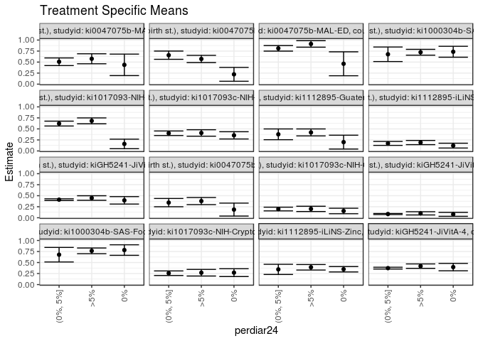

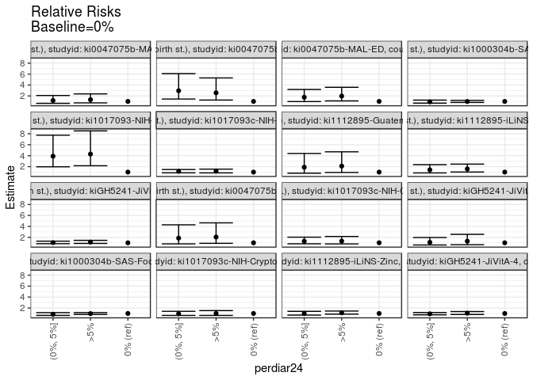

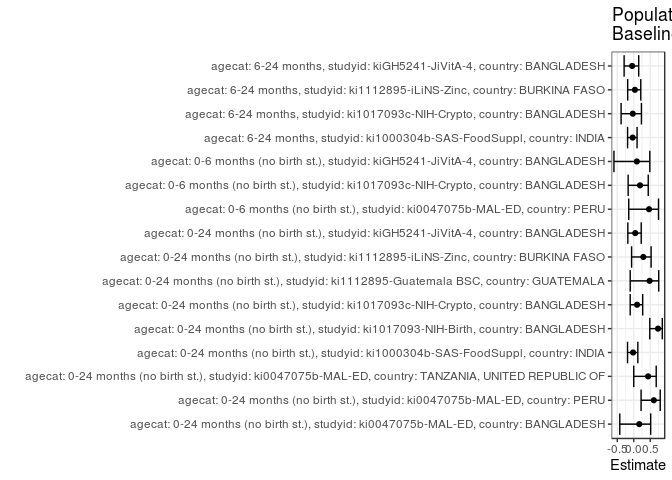

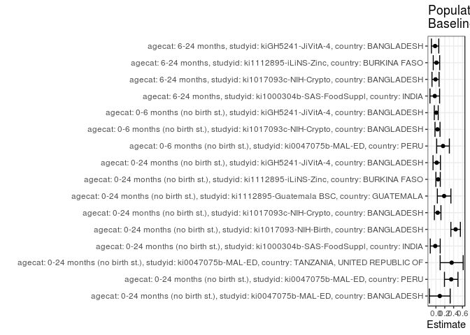

## Results Table

### Parameter: TSM

| agecat | studyid | country | intervention_level | baseline_level | estimate | ci_lower | ci_upper |
| --- | --- | --- | --- | --- | --- | --- | --- |
| 0-24 months (no birth st.) | ki0047075b-MAL-ED | BANGLADESH | 0% | NA | 0.4375000 | 0.1938640 | 0.6811360 |
| 0-24 months (no birth st.) | ki0047075b-MAL-ED | BANGLADESH | (0%, 5%] | NA | 0.5078125 | 0.4210038 | 0.5946212 |
| 0-24 months (no birth st.) | ki0047075b-MAL-ED | BANGLADESH | >5% | NA | 0.5753425 | 0.4616917 | 0.6889932 |
| 0-24 months (no birth st.) | ki0047075b-MAL-ED | PERU | 0% | NA | 0.2222222 | 0.0651116 | 0.3793329 |
| 0-24 months (no birth st.) | ki0047075b-MAL-ED | PERU | (0%, 5%] | NA | 0.6565657 | 0.5628506 | 0.7502807 |
| 0-24 months (no birth st.) | ki0047075b-MAL-ED | PERU | >5% | NA | 0.5714286 | 0.4892999 | 0.6535572 |
| 0-24 months (no birth st.) | ki0047075b-MAL-ED | TANZANIA, UNITED REPUBLIC OF | 0% | NA | 0.4615385 | 0.1899249 | 0.7331521 |
| 0-24 months (no birth st.) | ki0047075b-MAL-ED | TANZANIA, UNITED REPUBLIC OF | (0%, 5%] | NA | 0.8120805 | 0.7492119 | 0.8749492 |
| 0-24 months (no birth st.) | ki0047075b-MAL-ED | TANZANIA, UNITED REPUBLIC OF | >5% | NA | 0.9122807 | 0.8386742 | 0.9858872 |
| 0-24 months (no birth st.) | ki1000304b-SAS-FoodSuppl | INDIA | 0% | NA | 0.7346939 | 0.6108360 | 0.8585517 |
| 0-24 months (no birth st.) | ki1000304b-SAS-FoodSuppl | INDIA | (0%, 5%] | NA | 0.6774194 | 0.5125417 | 0.8422970 |
| 0-24 months (no birth st.) | ki1000304b-SAS-FoodSuppl | INDIA | >5% | NA | 0.7231638 | 0.6571192 | 0.7892085 |
| 0-24 months (no birth st.) | ki1017093-NIH-Birth | BANGLADESH | 0% | NA | 0.1590909 | 0.0509150 | 0.2672668 |
| 0-24 months (no birth st.) | ki1017093-NIH-Birth | BANGLADESH | (0%, 5%] | NA | 0.6208054 | 0.5656662 | 0.6759446 |
| 0-24 months (no birth st.) | ki1017093-NIH-Birth | BANGLADESH | >5% | NA | 0.6827957 | 0.6158507 | 0.7497407 |
| 0-24 months (no birth st.) | ki1017093c-NIH-Crypto | BANGLADESH | 0% | NA | 0.3538462 | 0.2715870 | 0.4361053 |
| 0-24 months (no birth st.) | ki1017093c-NIH-Crypto | BANGLADESH | (0%, 5%] | NA | 0.4011461 | 0.3496849 | 0.4526073 |
| 0-24 months (no birth st.) | ki1017093c-NIH-Crypto | BANGLADESH | >5% | NA | 0.4080460 | 0.3349649 | 0.4811270 |
| 0-24 months (no birth st.) | ki1112895-Guatemala BSC | GUATEMALA | 0% | NA | 0.2000000 | 0.0428696 | 0.3571304 |
| 0-24 months (no birth st.) | ki1112895-Guatemala BSC | GUATEMALA | (0%, 5%] | NA | 0.3770492 | 0.2551696 | 0.4989288 |
| 0-24 months (no birth st.) | ki1112895-Guatemala BSC | GUATEMALA | >5% | NA | 0.4200000 | 0.3408478 | 0.4991522 |
| 0-24 months (no birth st.) | ki1112895-iLiNS-Zinc | BURKINA FASO | 0% | NA | 0.1207547 | 0.0662963 | 0.1752131 |
| 0-24 months (no birth st.) | ki1112895-iLiNS-Zinc | BURKINA FASO | (0%, 5%] | NA | 0.1709647 | 0.1262482 | 0.2156811 |
| 0-24 months (no birth st.) | ki1112895-iLiNS-Zinc | BURKINA FASO | >5% | NA | 0.1906412 | 0.1430839 | 0.2381986 |
| 0-24 months (no birth st.) | kiGH5241-JiVitA-4 | BANGLADESH | 0% | NA | 0.3950617 | 0.3106674 | 0.4794561 |
| 0-24 months (no birth st.) | kiGH5241-JiVitA-4 | BANGLADESH | (0%, 5%] | NA | 0.4104410 | 0.3907193 | 0.4301628 |
| 0-24 months (no birth st.) | kiGH5241-JiVitA-4 | BANGLADESH | >5% | NA | 0.4475703 | 0.3960976 | 0.4990430 |
| 0-6 months (no birth st.) | ki0047075b-MAL-ED | PERU | 0% | NA | 0.1851852 | 0.0383884 | 0.3319820 |
| 0-6 months (no birth st.) | ki0047075b-MAL-ED | PERU | (0%, 5%] | NA | 0.3434343 | 0.2497193 | 0.4371494 |
| 0-6 months (no birth st.) | ki0047075b-MAL-ED | PERU | >5% | NA | 0.3785714 | 0.2980760 | 0.4590669 |
| 0-6 months (no birth st.) | ki1017093c-NIH-Crypto | BANGLADESH | 0% | NA | 0.1538462 | 0.0917768 | 0.2159155 |
| 0-6 months (no birth st.) | ki1017093c-NIH-Crypto | BANGLADESH | (0%, 5%] | NA | 0.1977077 | 0.1558914 | 0.2395241 |
| 0-6 months (no birth st.) | ki1017093c-NIH-Crypto | BANGLADESH | >5% | NA | 0.2011494 | 0.1415423 | 0.2607566 |
| 0-6 months (no birth st.) | kiGH5241-JiVitA-4 | BANGLADESH | 0% | NA | 0.0775194 | 0.0328339 | 0.1222049 |
| 0-6 months (no birth st.) | kiGH5241-JiVitA-4 | BANGLADESH | (0%, 5%] | NA | 0.0841772 | 0.0718082 | 0.0965462 |
| 0-6 months (no birth st.) | kiGH5241-JiVitA-4 | BANGLADESH | >5% | NA | 0.1000000 | 0.0633184 | 0.1366816 |
| 6-24 months | ki1000304b-SAS-FoodSuppl | INDIA | 0% | NA | 0.7826087 | 0.6631664 | 0.9020510 |
| 6-24 months | ki1000304b-SAS-FoodSuppl | INDIA | (0%, 5%] | NA | 0.6774194 | 0.5125232 | 0.8423156 |
| 6-24 months | ki1000304b-SAS-FoodSuppl | INDIA | >5% | NA | 0.7650602 | 0.7004330 | 0.8296875 |
| 6-24 months | ki1017093c-NIH-Crypto | BANGLADESH | 0% | NA | 0.2708333 | 0.1818504 | 0.3598162 |
| 6-24 months | ki1017093c-NIH-Crypto | BANGLADESH | (0%, 5%] | NA | 0.2572464 | 0.2056261 | 0.3088666 |
| 6-24 months | ki1017093c-NIH-Crypto | BANGLADESH | >5% | NA | 0.2686567 | 0.1935317 | 0.3437818 |
| 6-24 months | ki1112895-iLiNS-Zinc | BURKINA FASO | 0% | NA | 0.3473389 | 0.2859990 | 0.4086789 |
| 6-24 months | ki1112895-iLiNS-Zinc | BURKINA FASO | (0%, 5%] | NA | 0.3444109 | 0.2289358 | 0.4598859 |
| 6-24 months | ki1112895-iLiNS-Zinc | BURKINA FASO | >5% | NA | 0.3919271 | 0.3299132 | 0.4539410 |
| 6-24 months | kiGH5241-JiVitA-4 | BANGLADESH | 0% | NA | 0.3961039 | 0.3120327 | 0.4801751 |
| 6-24 months | kiGH5241-JiVitA-4 | BANGLADESH | (0%, 5%] | NA | 0.3722791 | 0.3518097 | 0.3927486 |
| 6-24 months | kiGH5241-JiVitA-4 | BANGLADESH | >5% | NA | 0.4177898 | 0.3675825 | 0.4679971 |

### Parameter: E(Y)

| agecat | studyid | country | intervention_level | baseline_level | estimate | ci_lower | ci_upper |
| --- | --- | --- | --- | --- | --- | --- | --- |
| 0-24 months (no birth st.) | ki0047075b-MAL-ED | BANGLADESH | NA | NA | 0.5253456 | 0.4587520 | 0.5919392 |
| 0-24 months (no birth st.) | ki0047075b-MAL-ED | PERU | NA | NA | 0.5676692 | 0.5080232 | 0.6273151 |
| 0-24 months (no birth st.) | ki0047075b-MAL-ED | TANZANIA, UNITED REPUBLIC OF | NA | NA | 0.8173516 | 0.7660617 | 0.8686415 |
| 0-24 months (no birth st.) | ki1000304b-SAS-FoodSuppl | INDIA | NA | NA | 0.7198444 | 0.6648337 | 0.7748550 |
| 0-24 months (no birth st.) | ki1017093-NIH-Birth | BANGLADESH | NA | NA | 0.6041667 | 0.5624147 | 0.6459187 |
| 0-24 months (no birth st.) | ki1017093c-NIH-Crypto | BANGLADESH | NA | NA | 0.3935681 | 0.3560687 | 0.4310676 |
| 0-24 months (no birth st.) | ki1112895-Guatemala BSC | GUATEMALA | NA | NA | 0.3855932 | 0.3233622 | 0.4478242 |
| 0-24 months (no birth st.) | ki1112895-iLiNS-Zinc | BURKINA FASO | NA | NA | 0.1699312 | 0.1379174 | 0.2019450 |
| 0-24 months (no birth st.) | kiGH5241-JiVitA-4 | BANGLADESH | NA | NA | 0.4135358 | 0.3953404 | 0.4317312 |
| 0-6 months (no birth st.) | ki0047075b-MAL-ED | PERU | NA | NA | 0.3458647 | 0.2885967 | 0.4031327 |
| 0-6 months (no birth st.) | ki1017093c-NIH-Crypto | BANGLADESH | NA | NA | 0.1898928 | 0.1597870 | 0.2199986 |
| 0-6 months (no birth st.) | kiGH5241-JiVitA-4 | BANGLADESH | NA | NA | 0.0855425 | 0.0741829 | 0.0969021 |
| 6-24 months | ki1000304b-SAS-FoodSuppl | INDIA | NA | NA | 0.7572016 | 0.7031798 | 0.8112234 |
| 6-24 months | ki1017093c-NIH-Crypto | BANGLADESH | NA | NA | 0.2628458 | 0.2244546 | 0.3012371 |
| 6-24 months | ki1112895-iLiNS-Zinc | BURKINA FASO | NA | NA | 0.3597387 | 0.2944602 | 0.4250171 |
| 6-24 months | kiGH5241-JiVitA-4 | BANGLADESH | NA | NA | 0.3779118 | 0.3593176 | 0.3965059 |

### Parameter: RR

| agecat | studyid | country | intervention_level | baseline_level | estimate | ci_lower | ci_upper |
| --- | --- | --- | --- | --- | --- | --- | --- |
| 0-24 months (no birth st.) | ki0047075b-MAL-ED | BANGLADESH | 0% | 0% | 1.0000000 | 1.0000000 | 1.000000 |
| 0-24 months (no birth st.) | ki0047075b-MAL-ED | BANGLADESH | (0%, 5%] | 0% | 1.1607143 | 0.6482404 | 2.078330 |
| 0-24 months (no birth st.) | ki0047075b-MAL-ED | BANGLADESH | >5% | 0% | 1.3150685 | 0.7283377 | 2.374455 |
| 0-24 months (no birth st.) | ki0047075b-MAL-ED | PERU | 0% | 0% | 1.0000000 | 1.0000000 | 1.000000 |
| 0-24 months (no birth st.) | ki0047075b-MAL-ED | PERU | (0%, 5%] | 0% | 2.9545455 | 1.4363174 | 6.077583 |
| 0-24 months (no birth st.) | ki0047075b-MAL-ED | PERU | >5% | 0% | 2.5714286 | 1.2498240 | 5.290541 |
| 0-24 months (no birth st.) | ki0047075b-MAL-ED | TANZANIA, UNITED REPUBLIC OF | 0% | 0% | 1.0000000 | 1.0000000 | 1.000000 |
| 0-24 months (no birth st.) | ki0047075b-MAL-ED | TANZANIA, UNITED REPUBLIC OF | (0%, 5%] | 0% | 1.7595078 | 0.9718709 | 3.185472 |
| 0-24 months (no birth st.) | ki0047075b-MAL-ED | TANZANIA, UNITED REPUBLIC OF | >5% | 0% | 1.9766082 | 1.0913124 | 3.580075 |
| 0-24 months (no birth st.) | ki1000304b-SAS-FoodSuppl | INDIA | 0% | 0% | 1.0000000 | 1.0000000 | 1.000000 |
| 0-24 months (no birth st.) | ki1000304b-SAS-FoodSuppl | INDIA | (0%, 5%] | 0% | 0.9220430 | 0.6857533 | 1.239751 |
| 0-24 months (no birth st.) | ki1000304b-SAS-FoodSuppl | INDIA | >5% | 0% | 0.9843063 | 0.8125721 | 1.192336 |
| 0-24 months (no birth st.) | ki1017093-NIH-Birth | BANGLADESH | 0% | 0% | 1.0000000 | 1.0000000 | 1.000000 |
| 0-24 months (no birth st.) | ki1017093-NIH-Birth | BANGLADESH | (0%, 5%] | 0% | 3.9022052 | 1.9656098 | 7.746810 |
| 0-24 months (no birth st.) | ki1017093-NIH-Birth | BANGLADESH | >5% | 0% | 4.2918587 | 2.1591716 | 8.531073 |
| 0-24 months (no birth st.) | ki1017093c-NIH-Crypto | BANGLADESH | 0% | 0% | 1.0000000 | 1.0000000 | 1.000000 |
| 0-24 months (no birth st.) | ki1017093c-NIH-Crypto | BANGLADESH | (0%, 5%] | 0% | 1.1336739 | 0.8693103 | 1.478432 |
| 0-24 months (no birth st.) | ki1017093c-NIH-Crypto | BANGLADESH | >5% | 0% | 1.1531734 | 0.8598956 | 1.546477 |
| 0-24 months (no birth st.) | ki1112895-Guatemala BSC | GUATEMALA | 0% | 0% | 1.0000000 | 1.0000000 | 1.000000 |
| 0-24 months (no birth st.) | ki1112895-Guatemala BSC | GUATEMALA | (0%, 5%] | 0% | 1.8852459 | 0.8061442 | 4.408829 |
| 0-24 months (no birth st.) | ki1112895-Guatemala BSC | GUATEMALA | >5% | 0% | 2.1000000 | 0.9361295 | 4.710887 |
| 0-24 months (no birth st.) | ki1112895-iLiNS-Zinc | BURKINA FASO | 0% | 0% | 1.0000000 | 1.0000000 | 1.000000 |
| 0-24 months (no birth st.) | ki1112895-iLiNS-Zinc | BURKINA FASO | (0%, 5%] | 0% | 1.4158011 | 0.8491833 | 2.360495 |
| 0-24 months (no birth st.) | ki1112895-iLiNS-Zinc | BURKINA FASO | >5% | 0% | 1.5787478 | 1.0128937 | 2.460717 |
| 0-24 months (no birth st.) | kiGH5241-JiVitA-4 | BANGLADESH | 0% | 0% | 1.0000000 | 1.0000000 | 1.000000 |
| 0-24 months (no birth st.) | kiGH5241-JiVitA-4 | BANGLADESH | (0%, 5%] | 0% | 1.0389289 | 0.8336696 | 1.294725 |
| 0-24 months (no birth st.) | kiGH5241-JiVitA-4 | BANGLADESH | >5% | 0% | 1.1329124 | 0.8866171 | 1.447627 |
| 0-6 months (no birth st.) | ki0047075b-MAL-ED | PERU | 0% | 0% | 1.0000000 | 1.0000000 | 1.000000 |
| 0-6 months (no birth st.) | ki0047075b-MAL-ED | PERU | (0%, 5%] | 0% | 1.8545455 | 0.8019448 | 4.288747 |
| 0-6 months (no birth st.) | ki0047075b-MAL-ED | PERU | >5% | 0% | 2.0442857 | 0.8997158 | 4.644916 |
| 0-6 months (no birth st.) | ki1017093c-NIH-Crypto | BANGLADESH | 0% | 0% | 1.0000000 | 1.0000000 | 1.000000 |
| 0-6 months (no birth st.) | ki1017093c-NIH-Crypto | BANGLADESH | (0%, 5%] | 0% | 1.2851003 | 0.8148975 | 2.026614 |
| 0-6 months (no birth st.) | ki1017093c-NIH-Crypto | BANGLADESH | >5% | 0% | 1.3074713 | 0.7925574 | 2.156918 |
| 0-6 months (no birth st.) | kiGH5241-JiVitA-4 | BANGLADESH | 0% | 0% | 1.0000000 | 1.0000000 | 1.000000 |
| 0-6 months (no birth st.) | kiGH5241-JiVitA-4 | BANGLADESH | (0%, 5%] | 0% | 1.0858861 | 0.6015514 | 1.960179 |
| 0-6 months (no birth st.) | kiGH5241-JiVitA-4 | BANGLADESH | >5% | 0% | 1.2900000 | 0.6534248 | 2.546735 |
| 6-24 months | ki1000304b-SAS-FoodSuppl | INDIA | 0% | 0% | 1.0000000 | 1.0000000 | 1.000000 |
| 6-24 months | ki1000304b-SAS-FoodSuppl | INDIA | (0%, 5%] | 0% | 0.8655914 | 0.6494369 | 1.153689 |
| 6-24 months | ki1000304b-SAS-FoodSuppl | INDIA | >5% | 0% | 0.9775770 | 0.8210947 | 1.163881 |
| 6-24 months | ki1017093c-NIH-Crypto | BANGLADESH | 0% | 0% | 1.0000000 | 1.0000000 | 1.000000 |
| 6-24 months | ki1017093c-NIH-Crypto | BANGLADESH | (0%, 5%] | 0% | 0.9498328 | 0.6463245 | 1.395866 |
| 6-24 months | ki1017093c-NIH-Crypto | BANGLADESH | >5% | 0% | 0.9919633 | 0.6443524 | 1.527101 |
| 6-24 months | ki1112895-iLiNS-Zinc | BURKINA FASO | 0% | 0% | 1.0000000 | 1.0000000 | 1.000000 |
| 6-24 months | ki1112895-iLiNS-Zinc | BURKINA FASO | (0%, 5%] | 0% | 0.9915700 | 0.7069321 | 1.390814 |
| 6-24 months | ki1112895-iLiNS-Zinc | BURKINA FASO | >5% | 0% | 1.1283707 | 0.8809977 | 1.445203 |
| 6-24 months | kiGH5241-JiVitA-4 | BANGLADESH | 0% | 0% | 1.0000000 | 1.0000000 | 1.000000 |
| 6-24 months | kiGH5241-JiVitA-4 | BANGLADESH | (0%, 5%] | 0% | 0.9398522 | 0.7543448 | 1.170979 |
| 6-24 months | kiGH5241-JiVitA-4 | BANGLADESH | >5% | 0% | 1.0547479 | 0.8233946 | 1.351106 |

### Parameter: PAR

| agecat | studyid | country | intervention_level | baseline_level | estimate | ci_lower | ci_upper |
| --- | --- | --- | --- | --- | --- | --- | --- |
| 0-24 months (no birth st.) | ki0047075b-MAL-ED | BANGLADESH | 0% | NA | 0.0878456 | -0.1467601 | 0.3224514 |
| 0-24 months (no birth st.) | ki0047075b-MAL-ED | PERU | 0% | NA | 0.3454470 | 0.1930317 | 0.4978622 |
| 0-24 months (no birth st.) | ki0047075b-MAL-ED | TANZANIA, UNITED REPUBLIC OF | 0% | NA | 0.3558131 | 0.0957246 | 0.6159017 |
| 0-24 months (no birth st.) | ki1000304b-SAS-FoodSuppl | INDIA | 0% | NA | -0.0148495 | -0.1267296 | 0.0970306 |
| 0-24 months (no birth st.) | ki1017093-NIH-Birth | BANGLADESH | 0% | NA | 0.4450758 | 0.3378614 | 0.5522901 |
| 0-24 months (no birth st.) | ki1017093c-NIH-Crypto | BANGLADESH | 0% | NA | 0.0397220 | -0.0342955 | 0.1137395 |
| 0-24 months (no birth st.) | ki1112895-Guatemala BSC | GUATEMALA | 0% | NA | 0.1855932 | 0.0328459 | 0.3383405 |
| 0-24 months (no birth st.) | ki1112895-iLiNS-Zinc | BURKINA FASO | 0% | NA | 0.0491765 | -0.0003923 | 0.0987452 |
| 0-24 months (no birth st.) | kiGH5241-JiVitA-4 | BANGLADESH | 0% | NA | 0.0184740 | -0.0648883 | 0.1018364 |
| 0-6 months (no birth st.) | ki0047075b-MAL-ED | PERU | 0% | NA | 0.1606795 | 0.0176611 | 0.3036979 |
| 0-6 months (no birth st.) | ki1017093c-NIH-Crypto | BANGLADESH | 0% | NA | 0.0360466 | -0.0207424 | 0.0928357 |
| 0-6 months (no birth st.) | kiGH5241-JiVitA-4 | BANGLADESH | 0% | NA | 0.0080231 | -0.0361600 | 0.0522062 |
| 6-24 months | ki1000304b-SAS-FoodSuppl | INDIA | 0% | NA | -0.0254070 | -0.1339590 | 0.0831449 |
| 6-24 months | ki1017093c-NIH-Crypto | BANGLADESH | 0% | NA | -0.0079875 | -0.0879087 | 0.0719337 |
| 6-24 months | ki1112895-iLiNS-Zinc | BURKINA FASO | 0% | NA | 0.0123997 | -0.0598453 | 0.0846448 |
| 6-24 months | kiGH5241-JiVitA-4 | BANGLADESH | 0% | NA | -0.0181921 | -0.1011553 | 0.0647710 |

### Parameter: PAF

| agecat | studyid | country | intervention_level | baseline_level | estimate | ci_lower | ci_upper |
| --- | --- | --- | --- | --- | --- | --- | --- |
| 0-24 months (no birth st.) | ki0047075b-MAL-ED | BANGLADESH | 0% | NA | 0.1672149 | -0.4244294 | 0.5131166 |
| 0-24 months (no birth st.) | ki0047075b-MAL-ED | PERU | 0% | NA | 0.6085357 | 0.2223258 | 0.8029454 |
| 0-24 months (no birth st.) | ki0047075b-MAL-ED | TANZANIA, UNITED REPUBLIC OF | 0% | NA | 0.4353245 | -0.0003772 | 0.6812617 |
| 0-24 months (no birth st.) | ki1000304b-SAS-FoodSuppl | INDIA | 0% | NA | -0.0206288 | -0.1885492 | 0.1235675 |
| 0-24 months (no birth st.) | ki1017093-NIH-Birth | BANGLADESH | 0% | NA | 0.7366771 | 0.4861982 | 0.8650473 |
| 0-24 months (no birth st.) | ki1017093c-NIH-Crypto | BANGLADESH | 0% | NA | 0.1009279 | -0.1083069 | 0.2706617 |
| 0-24 months (no birth st.) | ki1112895-Guatemala BSC | GUATEMALA | 0% | NA | 0.4813187 | -0.1075266 | 0.7570891 |
| 0-24 months (no birth st.) | ki1112895-iLiNS-Zinc | BURKINA FASO | 0% | NA | 0.2893905 | -0.0655755 | 0.5261097 |
| 0-24 months (no birth st.) | kiGH5241-JiVitA-4 | BANGLADESH | 0% | NA | 0.0446734 | -0.1796431 | 0.2263347 |
| 0-6 months (no birth st.) | ki0047075b-MAL-ED | PERU | 0% | NA | 0.4645733 | -0.1523338 | 0.7512164 |
| 0-6 months (no birth st.) | ki1017093c-NIH-Crypto | BANGLADESH | 0% | NA | 0.1898263 | -0.1705356 | 0.4392469 |
| 0-6 months (no birth st.) | kiGH5241-JiVitA-4 | BANGLADESH | 0% | NA | 0.0937910 | -0.6007716 | 0.4869882 |
| 6-24 months | ki1000304b-SAS-FoodSuppl | INDIA | 0% | NA | -0.0335539 | -0.1874566 | 0.1004020 |
| 6-24 months | ki1017093c-NIH-Crypto | BANGLADESH | 0% | NA | -0.0303885 | -0.3840601 | 0.2329087 |
| 6-24 months | ki1112895-iLiNS-Zinc | BURKINA FASO | 0% | NA | 0.0344687 | -0.1841874 | 0.2127508 |
| 6-24 months | kiGH5241-JiVitA-4 | BANGLADESH | 0% | NA | -0.0481386 | -0.2925197 | 0.1500366 |